# PLS - Hoteles

Artículo 1, versión 1 (Doctoranda Moreno)

Roberto Gil-Saura

2021-06-02

### 0.0.1 Notas

En este modelo sostenibilidad (SUS) mantiene todos sus ítems, mientras que *brand equity* (BEQ) solo toma la escala desde 35 a 38 (Yoo et al.).

# 1 Análisis del modelo de medida, multigrupo.

Seguidamente mostramos el modelo de medida (outer model) y el modelo estructural (inner model), establecidos a partir de las hipótesis lanzadas.

El modelo estructural es el siguiente:

[interactive chart not shown]

Modelo estructural

## 1.1 Fiabilidad del instrumento de medida

Para el modelo de medida se han considerado constructos de tipo composite mode_A (reflectivos). De este modo, el primer paso debe ser observar el resumen de los indicadores de fiabilidad, consistencia interna y validez.

```
Modelo
```

```
    alpha  rhoC   AVE  rhoA
ICT 0.855 0.903 0.699 0.855
SUS 0.924 0.933 0.490 0.950
BEQ 0.954 0.966 0.876 0.989
RVL 0.860 0.896 0.632 0.901
SST 0.856 0.912 0.777 0.876
EST 0.825 0.896 0.742 0.833

Alpha, rhoC, and rhoA should exceed 0.7 while AVE should exceed 0.5
```

```
Modelo grupo 1
```

```
    alpha  rhoC   AVE  rhoA
ICT 0.847 0.898 0.690 0.850
SUS 0.905 0.914 0.437 0.926
BEQ 0.957 0.967 0.882 1.017
RVL 0.886 0.823 0.498 0.585
SST 0.840 0.904 0.759 0.855
EST 0.847 0.908 0.767 0.860

Alpha, rhoC, and rhoA should exceed 0.7 while AVE should exceed 0.5
```

```
Modelo grupo 2
```

```
    alpha  rhoC   AVE  rhoA
ICT 0.810 0.872 0.629 0.839
SUS 0.927 0.935 0.495 0.958
BEQ 0.950 0.963 0.868 0.986
RVL 0.740 0.773 0.428 0.971
SST 0.861 0.915 0.781 0.892
EST 0.803 0.884 0.717 0.815

Alpha, rhoC, and rhoA should exceed 0.7 while AVE should exceed 0.5
```

El resultado del análisis muestra todas las escalas que apoyan las variables latentes tienen un *Cronbach’s alpha* mayor que 0.7, completado por una fiabilidad del compuesto *rhoC* también por encima de 0.7. para valores superiores a 0.9[^1].

## 1.2 Validez convergente

### 1.2.1 AVE (reflectivos)

```
Modelo
```

```
  ICT   SUS   BEQ   RVL   SST   EST
0.699 0.490 0.876 0.632 0.777 0.742
```

```
Modelo grupo 1
```

```
  ICT   SUS   BEQ   RVL   SST   EST
0.690 0.437 0.882 0.498 0.759 0.767
```

```
Modelo grupo 2
```

```
  ICT   SUS   BEQ   RVL   SST   EST
0.629 0.495 0.868 0.428 0.781 0.717
```

Los indicadores son mostrados de forma conjunta en el siguiente gráfico.

```
Modelo
```

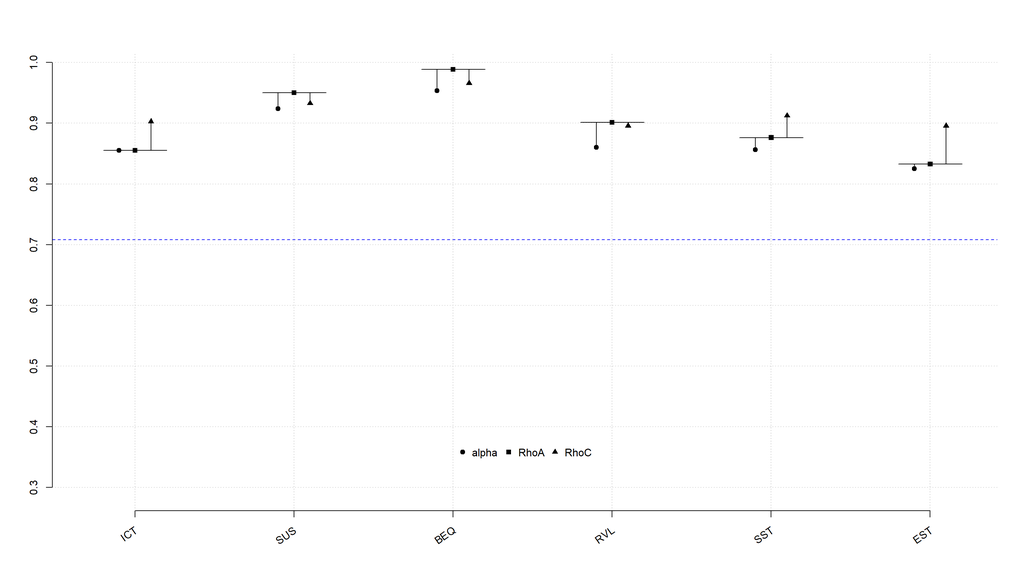

Tabla de fiabilidad

```
Modelo grupo 1
```

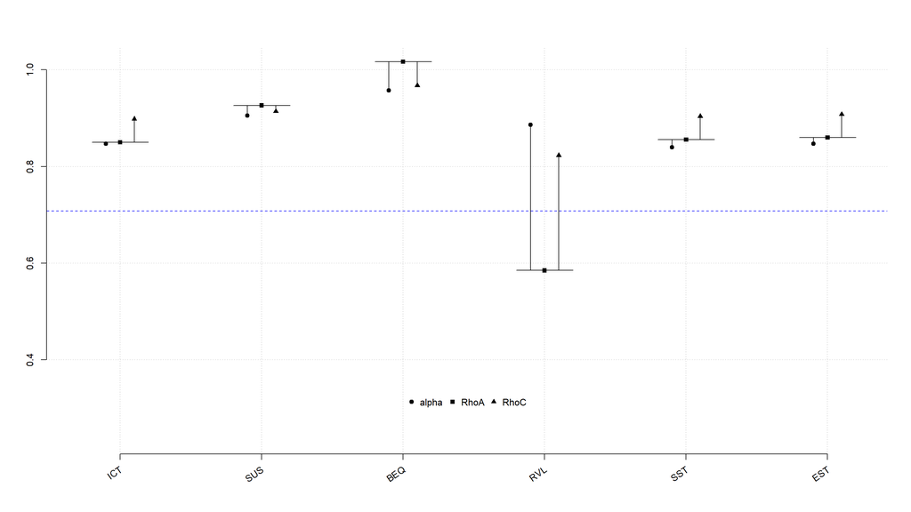

Tabla de fiabilidad

```
Modelo grupo 2
```

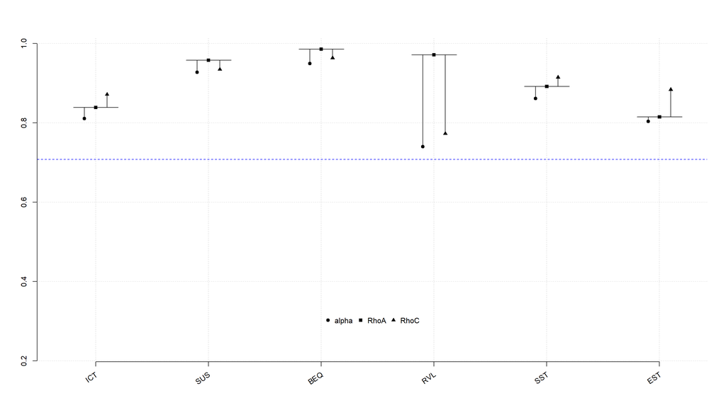

Tabla de fiabilidad

### 1.2.2 Análisis de las cargas (reflectivos) o de los pesos (formativos)

Por otro lado, es importante analizar también las cargas o *loadings*, indicadores de la fiabilidad del indicador en el constructo, y que deberían ser mayores de 0.7 para retener el indicador; para aquellas que están entre 0.4 y 0.7 debe ser analizado el comportamiento del constructo ante una eliminación del indicador con carga baja[^2].

```
Modelo
```

```
        ICT   SUS    BEQ   RVL   SST   EST
ICT1  0.853 0.000  0.000 0.000 0.000 0.000
ICT2  0.882 0.000  0.000 0.000 0.000 0.000
ICT3  0.853 0.000  0.000 0.000 0.000 0.000
ICT4  0.751 0.000  0.000 0.000 0.000 0.000
SUS1  0.000 0.765  0.000 0.000 0.000 0.000
SUS2  0.000 0.803  0.000 0.000 0.000 0.000
SUS3  0.000 0.762  0.000 0.000 0.000 0.000
SUS4  0.000 0.727  0.000 0.000 0.000 0.000
SUS5  0.000 0.679  0.000 0.000 0.000 0.000
SUS6  0.000 0.800  0.000 0.000 0.000 0.000
SUS7  0.000 0.696  0.000 0.000 0.000 0.000
SUS8  0.000 0.690  0.000 0.000 0.000 0.000
SUS9  0.000 0.396 -0.000 0.000 0.000 0.000
SUS10 0.000 0.802  0.000 0.000 0.000 0.000
SUS11 0.000 0.840  0.000 0.000 0.000 0.000
SUS12 0.000 0.812  0.000 0.000 0.000 0.000
SUS13 0.000 0.515  0.000 0.000 0.000 0.000
SUS14 0.000 0.482  0.000 0.000 0.000 0.000
SUS15 0.000 0.534  0.000 0.000 0.000 0.000
BEQ7  0.000 0.000  0.910 0.000 0.000 0.000
BEQ8  0.000 0.000  0.930 0.000 0.000 0.000
BEQ9  0.000 0.000  0.951 0.000 0.000 0.000
BEQ10 0.000 0.000  0.952 0.000 0.000 0.000
RVL1  0.000 0.000  0.000 0.781 0.000 0.000
RVL2  0.000 0.000  0.000 0.783 0.000 0.000
RVL3  0.000 0.000  0.000 0.819 0.000 0.000
RVL4  0.000 0.000  0.000 0.778 0.000 0.000
RVL5  0.000 0.000  0.000 0.814 0.000 0.000
SST1  0.000 0.000  0.000 0.000 0.815 0.000
SST2  0.000 0.000  0.000 0.000 0.931 0.000
SST3  0.000 0.000  0.000 0.000 0.895 0.000
EST1  0.000 0.000  0.000 0.000 0.000 0.858
EST2  0.000 0.000  0.000 0.000 0.000 0.904
EST3  0.000 0.000  0.000 0.000 0.000 0.819
```

```
Modelo grupo 1
```

```
        ICT   SUS    BEQ    RVL    SST    EST
ICT1  0.884 0.000  0.000  0.000  0.000  0.000
ICT2  0.879 0.000  0.000  0.000  0.000  0.000
ICT3  0.829 0.000  0.000  0.000  0.000  0.000
ICT4  0.721 0.000  0.000  0.000  0.000  0.000
SUS1  0.000 0.838  0.000  0.000  0.000  0.000
SUS2  0.000 0.833  0.000  0.000  0.000  0.000
SUS3  0.000 0.665  0.000  0.000  0.000  0.000
SUS4  0.000 0.732  0.000  0.000  0.000  0.000
SUS5  0.000 0.575  0.000  0.000  0.000  0.000
SUS6  0.000 0.802  0.000  0.000  0.000  0.000
SUS7  0.000 0.776  0.000  0.000  0.000  0.000
SUS8  0.000 0.657  0.000  0.000  0.000  0.000
SUS9  0.000 0.369  0.000  0.000 -0.000  0.000
SUS10 0.000 0.786  0.000  0.000  0.000  0.000
SUS11 0.000 0.765  0.000  0.000  0.000  0.000
SUS12 0.000 0.722  0.000  0.000  0.000  0.000
SUS13 0.000 0.318 -0.000  0.000 -0.000 -0.000
SUS14 0.000 0.300 -0.000  0.000 -0.000  0.000
SUS15 0.000 0.336 -0.000  0.000 -0.000 -0.000
BEQ7  0.000 0.000  0.927  0.000  0.000  0.000
BEQ8  0.000 0.000  0.920 -0.000  0.000  0.000
BEQ9  0.000 0.000  0.961  0.000  0.000  0.000
BEQ10 0.000 0.000  0.947  0.000  0.000  0.000
RVL1  0.000 0.000  0.000  0.525  0.000  0.000
RVL2  0.000 0.000 -0.000  0.495  0.000  0.000
RVL3  0.000 0.000  0.000  0.625 -0.000  0.000
RVL4  0.000 0.000  0.000  0.819 -0.000  0.000
RVL5  0.000 0.000  0.000  0.953 -0.000  0.000
SST1  0.000 0.000  0.000 -0.000  0.796  0.000
SST2  0.000 0.000  0.000 -0.000  0.941  0.000
SST3  0.000 0.000  0.000 -0.000  0.872  0.000
EST1  0.000 0.000  0.000  0.000  0.000  0.894
EST2  0.000 0.000 -0.000  0.000  0.000  0.920
EST3  0.000 0.000  0.000  0.000  0.000  0.810
```

```
Modelo grupo 2
```

```
         ICT   SUS    BEQ   RVL    SST    EST
ICT1   0.781 0.000  0.000 0.000  0.000 -0.000
ICT2   0.798 0.000  0.000 0.000  0.000  0.000
ICT3   0.789 0.000  0.000 0.000  0.000 -0.000
ICT4   0.804 0.000  0.000 0.000  0.000  0.000
SUS1   0.000 0.670  0.000 0.000  0.000  0.000
SUS2   0.000 0.747  0.000 0.000  0.000  0.000
SUS3   0.000 0.808 -0.000 0.000  0.000  0.000
SUS4   0.000 0.742  0.000 0.000  0.000  0.000
SUS5   0.000 0.780  0.000 0.000  0.000  0.000
SUS6   0.000 0.748  0.000 0.000  0.000 -0.000
SUS7   0.000 0.654  0.000 0.000  0.000 -0.000
SUS8   0.000 0.774  0.000 0.000  0.000  0.000
SUS9   0.000 0.637 -0.000 0.000  0.000  0.000
SUS10  0.000 0.746  0.000 0.000  0.000  0.000
SUS11  0.000 0.849  0.000 0.000  0.000  0.000
SUS12  0.000 0.803  0.000 0.000  0.000  0.000
SUS13  0.000 0.486 -0.000 0.000  0.000  0.000
SUS14  0.000 0.474  0.000 0.000  0.000  0.000
SUS15  0.000 0.487  0.000 0.000  0.000  0.000
BEQ7   0.000 0.000  0.885 0.000  0.000  0.000
BEQ8   0.000 0.000  0.926 0.000  0.000  0.000
BEQ9   0.000 0.000  0.953 0.000  0.000  0.000
BEQ10  0.000 0.000  0.960 0.000  0.000  0.000
RVL1   0.000 0.000 -0.000 0.797  0.000  0.000
RVL2   0.000 0.000  0.000 0.925  0.000  0.000
RVL3   0.000 0.000  0.000 0.494 -0.000 -0.000
RVL4   0.000 0.000  0.000 0.434 -0.000  0.000
RVL5   0.000 0.000  0.000 0.468  0.000  0.000
SST1   0.000 0.000  0.000 0.000  0.821  0.000
SST2   0.000 0.000  0.000 0.000  0.921  0.000
SST3   0.000 0.000  0.000 0.000  0.907  0.000
EST1  -0.000 0.000  0.000 0.000  0.000  0.818
EST2   0.000 0.000  0.000 0.000  0.000  0.889
EST3  -0.000 0.000  0.000 0.000  0.000  0.833
```

## 1.3 Validez discriminante

### 1.3.1 Cross-loadings

Para el análisis de la validez discriminante o capacidad de un constructo de ser realmente distinto a otros, utilizamos las denominadas *cross-loadings*, que miden esa capacidad del constructo. En la tabla adjunta se puede observar en cada indicador carga de forma superior en su variable latente, siendo el resto de cargas de menor intensidad.

```
Modelo
```

```
        ICT   SUS    BEQ   RVL   SST   EST
ICT1  0.853 0.365  0.132 0.250 0.127 0.081
ICT2  0.882 0.383  0.238 0.286 0.168 0.110
ICT3  0.853 0.369  0.278 0.252 0.109 0.011
ICT4  0.751 0.375  0.132 0.264 0.175 0.051
SUS1  0.282 0.765  0.168 0.339 0.224 0.218
SUS2  0.339 0.803  0.148 0.344 0.173 0.162
SUS3  0.303 0.762  0.043 0.299 0.203 0.143
SUS4  0.287 0.727  0.112 0.294 0.237 0.195
SUS5  0.251 0.679  0.170 0.178 0.198 0.112
SUS6  0.346 0.800  0.183 0.233 0.230 0.104
SUS7  0.323 0.696  0.169 0.251 0.103 0.035
SUS8  0.276 0.690  0.116 0.380 0.164 0.151
SUS9  0.172 0.396 -0.020 0.196 0.042 0.083
SUS10 0.420 0.802  0.211 0.378 0.298 0.201
SUS11 0.434 0.840  0.265 0.371 0.308 0.214
SUS12 0.438 0.812  0.312 0.323 0.344 0.214
SUS13 0.135 0.515  0.027 0.283 0.126 0.104
SUS14 0.176 0.482  0.053 0.275 0.144 0.140
SUS15 0.226 0.534  0.045 0.331 0.101 0.084
BEQ7  0.206 0.233  0.910 0.183 0.323 0.336
BEQ8  0.178 0.144  0.930 0.064 0.268 0.277
BEQ9  0.229 0.200  0.951 0.078 0.259 0.276
BEQ10 0.248 0.234  0.952 0.092 0.276 0.248
RVL1  0.188 0.333  0.032 0.781 0.096 0.207
RVL2  0.206 0.307  0.033 0.783 0.096 0.238
RVL3  0.241 0.269  0.118 0.819 0.008 0.103
RVL4  0.215 0.316  0.094 0.778 0.025 0.123
RVL5  0.337 0.419  0.144 0.814 0.037 0.122
SST1  0.213 0.298  0.271 0.052 0.815 0.557
SST2  0.140 0.278  0.241 0.047 0.931 0.725
SST3  0.122 0.226  0.300 0.051 0.895 0.738
EST1  0.039 0.160  0.223 0.142 0.631 0.858
EST2  0.118 0.227  0.246 0.156 0.726 0.904
EST3  0.031 0.156  0.331 0.178 0.631 0.819
```

```
Modelo grupo 1
```

```
        ICT   SUS    BEQ    RVL    SST    EST
ICT1  0.884 0.286  0.032  0.170  0.132  0.095
ICT2  0.879 0.302  0.146  0.177  0.161  0.097
ICT3  0.829 0.277  0.147  0.086  0.058  0.013
ICT4  0.721 0.275  0.093  0.125  0.041  0.001
SUS1  0.220 0.838  0.220  0.311  0.326  0.306
SUS2  0.283 0.833  0.200  0.343  0.257  0.268
SUS3  0.213 0.665  0.008  0.218  0.191  0.197
SUS4  0.273 0.732  0.133  0.300  0.225  0.220
SUS5  0.146 0.575  0.123  0.077  0.183  0.170
SUS6  0.312 0.802  0.181  0.278  0.228  0.157
SUS7  0.302 0.776  0.132  0.304  0.133  0.184
SUS8  0.242 0.657  0.104  0.391  0.062  0.153
SUS9  0.217 0.369  0.007  0.272 -0.075  0.053
SUS10 0.272 0.786  0.155  0.281  0.145  0.114
SUS11 0.228 0.765  0.180  0.279  0.192  0.165
SUS12 0.225 0.722  0.217  0.262  0.177  0.093
SUS13 0.005 0.318 -0.058  0.145 -0.078 -0.031
SUS14 0.066 0.300 -0.036  0.145 -0.024  0.039
SUS15 0.063 0.336 -0.060  0.166 -0.081 -0.028
BEQ7  0.121 0.200  0.927  0.197  0.103  0.169
BEQ8  0.040 0.105  0.920 -0.027  0.121  0.055
BEQ9  0.128 0.197  0.961  0.077  0.020  0.011
BEQ10 0.138 0.204  0.947  0.062  0.068  0.010
RVL1  0.122 0.363  0.010  0.525  0.032  0.219
RVL2  0.200 0.315 -0.042  0.495  0.009  0.210
RVL3  0.191 0.272  0.050  0.625 -0.027  0.175
RVL4  0.096 0.375  0.051  0.819 -0.061  0.163
RVL5  0.184 0.378  0.106  0.953 -0.112  0.095
SST1  0.172 0.286  0.054 -0.021  0.796  0.602
SST2  0.066 0.218  0.048 -0.132  0.941  0.743
SST3  0.090 0.151  0.098 -0.124  0.872  0.716
EST1  0.002 0.225  0.088  0.063  0.718  0.894
EST2  0.073 0.193 -0.010  0.014  0.747  0.920
EST3  0.100 0.223  0.134  0.264  0.607  0.810
```

```
Modelo grupo 2
```

```
         ICT   SUS    BEQ   RVL    SST    EST
ICT1   0.781 0.289  0.121 0.080  0.004 -0.027
ICT2   0.798 0.232  0.234 0.078  0.017  0.001
ICT3   0.789 0.224  0.286 0.003  0.012 -0.112
ICT4   0.804 0.386  0.099 0.215  0.224  0.029
SUS1   0.177 0.670  0.070 0.158  0.049  0.079
SUS2   0.234 0.747  0.050 0.158  0.019  0.015
SUS3   0.265 0.808 -0.006 0.206  0.147  0.053
SUS4   0.247 0.742  0.070 0.140  0.214  0.152
SUS5   0.281 0.780  0.163 0.118  0.168  0.038
SUS6   0.189 0.748  0.102 0.052  0.140 -0.012
SUS7   0.285 0.654  0.154 0.062  0.036 -0.096
SUS8   0.271 0.774  0.100 0.211  0.227  0.121
SUS9   0.255 0.637 -0.005 0.151  0.210  0.142
SUS10  0.258 0.746  0.136 0.286  0.337  0.189
SUS11  0.398 0.849  0.227 0.281  0.307  0.173
SUS12  0.386 0.803  0.290 0.213  0.381  0.225
SUS13  0.056 0.486 -0.000 0.103  0.261  0.182
SUS14  0.110 0.474  0.046 0.079  0.256  0.193
SUS15  0.171 0.487  0.019 0.177  0.185  0.113
BEQ7   0.150 0.168  0.885 0.047  0.423  0.415
BEQ8   0.181 0.093  0.926 0.060  0.327  0.393
BEQ9   0.215 0.145  0.953 0.049  0.379  0.422
BEQ10  0.239 0.197  0.960 0.053  0.374  0.374
RVL1   0.128 0.167 -0.012 0.797  0.120  0.155
RVL2   0.076 0.208  0.063 0.925  0.165  0.258
RVL3   0.171 0.161  0.137 0.494 -0.025 -0.024
RVL4   0.125 0.073  0.045 0.434 -0.007  0.009
RVL5   0.174 0.210  0.054 0.468  0.022  0.025
SST1   0.190 0.307  0.385 0.096  0.821  0.505
SST2   0.105 0.280  0.333 0.173  0.921  0.702
SST3   0.016 0.193  0.377 0.117  0.907  0.747
EST1  -0.030 0.057  0.276 0.183  0.544  0.818
EST2   0.045 0.192  0.373 0.275  0.695  0.889
EST3  -0.082 0.103  0.430 0.098  0.653  0.833
```

### 1.3.2 Fornell-Larcker

El criterio de Fornell-Larcker, compara la raíz cuadrado del *AVE* con la correlación de las variables latentes. La raíz cuadrada del AVE de cada constructo, debería ser más grande que la más alta correlación con cualquier otro constructo. Se puede observar en la tabla siguiente que el valor en la diagonal principal, es mayor que el resto de valores en la parte inferior de la matriz.

```
Modelo
```

```
      ICT   SUS   BEQ   RVL   SST   EST
ICT 0.836     .     .     .     .     .
SUS 0.447 0.700     .     .     .     .
BEQ 0.234 0.225 0.936     .     .     .
RVL 0.316 0.422 0.121 0.795     .     .
SST 0.174 0.299 0.306 0.056 0.881     .
EST 0.076 0.213 0.308 0.184 0.772 0.861

FL Criteria table reports square root of AVE on the diagonal and construct correlations on the lower triangle.
```

```
Modelo grupo 1
```

```
      ICT   SUS   BEQ    RVL   SST   EST
ICT 0.830     .     .      .     .     .
SUS 0.344 0.661     .      .     .     .
BEQ 0.127 0.202 0.939      .     .     .
RVL 0.170 0.390 0.111  0.706     .     .
SST 0.120 0.245 0.077 -0.111 0.871     .
EST 0.064 0.242 0.075  0.118 0.792 0.876

FL Criteria table reports square root of AVE on the diagonal and construct correlations on the lower triangle.
```

```
Modelo grupo 2
```

```
       ICT   SUS   BEQ   RVL   SST   EST
ICT  0.793     .     .     .     .     .
SUS  0.375 0.704     .     .     .     .
BEQ  0.214 0.171 0.932     .     .     .
RVL  0.139 0.238 0.055 0.654     .     .
SST  0.105 0.285 0.408 0.149 0.884     .
EST -0.024 0.144 0.429 0.221 0.751 0.847

FL Criteria table reports square root of AVE on the diagonal and construct correlations on the lower triangle.
```

### 1.3.3 HTMT

Por último el HTMT es un ratio que si es mayor que 0.90 indica una pérdida de validez discriminante.

```
Modelo
```

```
      ICT   SUS   BEQ   RVL   SST EST
ICT     .     .     .     .     .   .
SUS 0.475     .     .     .     .   .
BEQ 0.254 0.202     .     .     .   .
RVL 0.345 0.474 0.115     .     .   .
SST 0.210 0.318 0.334 0.086     .   .
EST 0.098 0.236 0.344 0.236 0.907   .
```

```
Modelo grupo 1
```

```
      ICT   SUS   BEQ   RVL   SST EST
ICT     .     .     .     .     .   .
SUS 0.359     .     .     .     .   .
BEQ 0.128 0.206     .     .     .   .
RVL 0.221 0.500 0.131     .     .   .
SST 0.170 0.292 0.094 0.082     .   .
EST 0.094 0.260 0.111 0.252 0.933   .
```

```
Modelo grupo 2
```

```
      ICT   SUS   BEQ   RVL   SST EST
ICT     .     .     .     .     .   .
SUS 0.379     .     .     .     .   .
BEQ 0.261 0.146     .     .     .   .
RVL 0.250 0.274 0.108     .     .   .
SST 0.163 0.325 0.450 0.154     .   .
EST 0.111 0.206 0.488 0.194 0.877   .
```

El ratio HTMT nos indica que los indicadores que pertenecen a una determinada variables latente están correlacionando más como otra variable latente que con la propia. HT/MT> 0.85 Clark & Watson, > 0.90 Gold et al. 2001; Teo et al. 2008).

**Atención SST con EST tiene un valor de 0.907!!!**

# 2 Análisis del modelo estructural

Una vez analizados los constructos desde el punto de vista de su composición, debemos analizar el modelo estructural en su conjunto. Partiendo de que el objetivo del PLS es la maximización de la varianza explicada, las medidas más importantes son la fiabilidad, la validez convergente y la validez discriminante del conjunto del modelo.

- Paths o cargas de latentes…
- R<sup>2</sup>, coeficiente de determinación y/o % de varianza explicada
- f<sup>2</sup> y q<sup>2</sup> efecto tamaño
- Q<sup>2</sup>, relevancia predictiva

## 2.1 Paths y R<sup>2</sup>

```
Modelo
```

```
         SUS   BEQ   RVL    SST   EST
R^2    0.200 0.051 0.015  0.003 0.596
AdjR^2 0.197 0.047 0.011 -0.001 0.594
ICT    0.447     .     .      .     .
SUS        . 0.225     .      .     .
BEQ        .     . 0.121      .     .
RVL        .     .     .  0.056     .
SST        .     .     .      . 0.772
```

```
Modelo grupo 1
```

```
         SUS   BEQ   RVL    SST   EST
R^2    0.118 0.041 0.012  0.012 0.628
AdjR^2 0.112 0.034 0.005  0.005 0.625
ICT    0.344     .     .      .     .
SUS        . 0.202     .      .     .
BEQ        .     . 0.111      .     .
RVL        .     .     . -0.111     .
SST        .     .     .      . 0.792
```

```
Modelo grupo 2
```

```
         SUS   BEQ    RVL   SST   EST
R^2    0.140 0.029  0.003 0.022 0.564
AdjR^2 0.134 0.022 -0.005 0.015 0.560
ICT    0.375     .      .     .     .
SUS        . 0.171      .     .     .
BEQ        .     .  0.055     .     .
RVL        .     .      . 0.149     .
SST        .     .      .     . 0.751
```

Buscar R<sup>2</sup> mayores de 0.7, aunque valores alrededor de 0.25 sean aceptados según ámbitos; (sustancial mayor que 0.75, moderado alrededor de 0.5 y débil, 0.25). Usar R<sup>2</sup><sub>adj</sub> para comparar modelos con diferente número de constructos y/u observaciones.

## 2.2 f<sup>2</sup> - effect sizes

El f<sup>2</sup> permite evaluar la contribución de cada constructo exógeno a la R<sup>2</sup> de un constructo endógeno. Los valores de 0.02, 0.15 y 0.35 indican un efecto pequeño, mediano o grande sobre el constructo endógeno.

```
Modelo
```

```
      ICT   SUS   BEQ   RVL   SST   EST
ICT 0.000 0.250 0.000 0.000 0.000 0.000
SUS 0.000 0.000 0.053 0.000 0.000 0.000
BEQ 0.000 0.000 0.000 0.015 0.000 0.000
RVL 0.000 0.000 0.000 0.000 0.003 0.000
SST 0.000 0.000 0.000 0.000 0.000 1.473
EST 0.000 0.000 0.000 0.000 0.000 0.000
```

```
Modelo grupo 1
```

```
      ICT   SUS   BEQ   RVL   SST   EST
ICT 0.000 0.134 0.000 0.000 0.000 0.000
SUS 0.000 0.000 0.043 0.000 0.000 0.000
BEQ 0.000 0.000 0.000 0.013 0.000 0.000
RVL 0.000 0.000 0.000 0.000 0.012 0.000
SST 0.000 0.000 0.000 0.000 0.000 1.686
EST 0.000 0.000 0.000 0.000 0.000 0.000
```

```
Modelo grupo 2
```

```
      ICT   SUS   BEQ   RVL   SST   EST
ICT 0.000 0.163 0.000 0.000 0.000 0.000
SUS 0.000 0.000 0.030 0.000 0.000 0.000
BEQ 0.000 0.000 0.000 0.003 0.000 0.000
RVL 0.000 0.000 0.000 0.000 0.023 0.000
SST 0.000 0.000 0.000 0.000 0.000 1.291
EST 0.000 0.000 0.000 0.000 0.000 0.000
```

## 2.3 Efectos

### 2.3.1 Totales

```
Modelo
```

```
      ICT   SUS   BEQ   RVL   SST   EST
ICT 0.000 0.447 0.101 0.012 0.001 0.001
SUS 0.000 0.000 0.225 0.027 0.002 0.001
BEQ 0.000 0.000 0.000 0.121 0.007 0.005
RVL 0.000 0.000 0.000 0.000 0.056 0.044
SST 0.000 0.000 0.000 0.000 0.000 0.772
EST 0.000 0.000 0.000 0.000 0.000 0.000
```

```
Modelo grupo 1
```

```
      ICT   SUS   BEQ   RVL    SST    EST
ICT 0.000 0.344 0.070 0.000  0.000  0.000
SUS 0.000 0.000 0.202 0.023  0.000  0.000
BEQ 0.000 0.000 0.000 0.111 -0.012  0.000
RVL 0.000 0.000 0.000 0.000 -0.111 -0.088
SST 0.000 0.000 0.000 0.000  0.000  0.792
EST 0.000 0.000 0.000 0.000  0.000  0.000
```

```
Modelo grupo 2
```

```
      ICT   SUS   BEQ   RVL   SST   EST
ICT 0.000 0.375 0.064 0.004 0.001 0.000
SUS 0.000 0.000 0.171 0.009 0.001 0.001
BEQ 0.000 0.000 0.000 0.055 0.008 0.006
RVL 0.000 0.000 0.000 0.000 0.149 0.112
SST 0.000 0.000 0.000 0.000 0.000 0.751
EST 0.000 0.000 0.000 0.000 0.000 0.000
```

### 2.3.2 Indirectos

```
Modelo
```

```
      ICT   SUS   BEQ   RVL   SST   EST
ICT 0.000 0.000 0.101 0.012 0.001 0.001
SUS 0.000 0.000 0.000 0.027 0.002 0.001
BEQ 0.000 0.000 0.000 0.000 0.007 0.005
RVL 0.000 0.000 0.000 0.000 0.000 0.044
SST 0.000 0.000 0.000 0.000 0.000 0.000
EST 0.000 0.000 0.000 0.000 0.000 0.000
```

```
Modelo grupo 1
```

```
      ICT   SUS   BEQ   RVL    SST    EST
ICT 0.000 0.000 0.070 0.000  0.000  0.000
SUS 0.000 0.000 0.000 0.023  0.000  0.000
BEQ 0.000 0.000 0.000 0.000 -0.012  0.000
RVL 0.000 0.000 0.000 0.000  0.000 -0.088
SST 0.000 0.000 0.000 0.000  0.000  0.000
EST 0.000 0.000 0.000 0.000  0.000  0.000
```

```
Modelo grupo 2
```

```
      ICT   SUS   BEQ   RVL   SST   EST
ICT 0.000 0.000 0.064 0.004 0.001 0.000
SUS 0.000 0.000 0.000 0.009 0.001 0.001
BEQ 0.000 0.000 0.000 0.000 0.008 0.006
RVL 0.000 0.000 0.000 0.000 0.000 0.112
SST 0.000 0.000 0.000 0.000 0.000 0.000
EST 0.000 0.000 0.000 0.000 0.000 0.000
```

### 2.3.3 it_criteria

```
Modelo
```

```
        SUS     BEQ    RVL   SST      EST
AIC -56.721 -10.927 -0.955 2.143 -239.684
BIC -49.539  -3.746  6.227 9.325 -232.502
```

```
Modelo grupo 1
```

```
        SUS    BEQ   RVL   SST      EST
AIC -14.153 -2.697 1.302 1.311 -131.390
BIC  -8.328  3.128 7.128 7.136 -125.565
```

```
Modelo grupo 2
```

```
        SUS    BEQ   RVL   SST      EST
AIC -16.960 -0.917 2.592 0.049 -106.442
BIC -11.195  4.849 8.358 5.815 -100.676
```

# 3 Modelización con bootstrapping

*Bootstrapping* para calcular la significatividad de los paths estimados. Habitualmente se trabaja con un 5% (t > 1.96) lo que implica significatividad al 95%. Podemos cambiar al 10 o al 1 según ámbito. Usar doble *bootstrapping* si hay menos de 4 constructos.

## 3.1 Structural paths

```
Modelo
```

```
             Original Est. Bootstrap Mean Bootstrap SD T Stat. 2.5% CI 97.5% CI
ICT  ->  SUS         0.447          0.457        0.058   7.655   0.342    0.560
SUS  ->  BEQ         0.225          0.241        0.064   3.538   0.131    0.357
BEQ  ->  RVL         0.121          0.145        0.071   1.694   0.005    0.274
RVL  ->  SST         0.056          0.056        0.081   0.700  -0.126    0.192
SST  ->  EST         0.772          0.770        0.034  22.976   0.717    0.834
```

```
Modelo grupo 1
```

```
             Original Est. Bootstrap Mean Bootstrap SD T Stat. 2.5% CI 97.5% CI
ICT  ->  SUS         0.344          0.381        0.085   4.071   0.216    0.541
SUS  ->  BEQ         0.202          0.166        0.245   0.825  -0.475    0.488
BEQ  ->  RVL         0.111         -0.009        0.350   0.318  -0.693    0.725
RVL  ->  SST        -0.111         -0.027        0.134  -0.831  -0.255    0.261
SST  ->  EST         0.792          0.790        0.045  17.632   0.701    0.857
```

```
Modelo grupo 2
```

```
             Original Est. Bootstrap Mean Bootstrap SD T Stat. 2.5% CI 97.5% CI
ICT  ->  SUS         0.375          0.405        0.057   6.582   0.309    0.525
SUS  ->  BEQ         0.171          0.178        0.108   1.589  -0.019    0.361
BEQ  ->  RVL         0.055          0.114        0.125   0.443  -0.137    0.322
RVL  ->  SST         0.149          0.112        0.164   0.905  -0.199    0.317
SST  ->  EST         0.751          0.752        0.052  14.459   0.635    0.832
```

## 3.2 Bootstrapped loadings

```
Modelo
```

```
               Original Est. Bootstrap Mean Bootstrap SD T Stat. 2.5% CI 97.5% CI
ICT1  ->  ICT          0.853          0.848        0.023  36.615   0.798    0.894
ICT2  ->  ICT          0.882          0.883        0.018  49.199   0.841    0.912
ICT3  ->  ICT          0.853          0.850        0.023  36.981   0.793    0.884
ICT4  ->  ICT          0.751          0.742        0.042  17.873   0.649    0.818
SUS1  ->  SUS          0.765          0.759        0.038  20.399   0.684    0.822
SUS2  ->  SUS          0.803          0.799        0.035  22.641   0.727    0.858
SUS3  ->  SUS          0.762          0.756        0.038  19.980   0.678    0.821
SUS4  ->  SUS          0.727          0.717        0.058  12.606   0.590    0.807
SUS5  ->  SUS          0.679          0.676        0.041  16.629   0.599    0.755
SUS6  ->  SUS          0.800          0.799        0.029  27.606   0.741    0.852
SUS7  ->  SUS          0.696          0.689        0.048  14.433   0.596    0.775
SUS8  ->  SUS          0.690          0.679        0.042  16.405   0.587    0.739
SUS9  ->  SUS          0.396          0.364        0.091   4.370   0.184    0.530
SUS10  ->  SUS         0.802          0.800        0.027  29.654   0.751    0.845
SUS11  ->  SUS         0.840          0.837        0.019  43.817   0.804    0.875
SUS12  ->  SUS         0.812          0.812        0.022  36.225   0.767    0.849
SUS13  ->  SUS         0.515          0.502        0.062   8.274   0.386    0.605
SUS14  ->  SUS         0.482          0.470        0.065   7.462   0.349    0.584
SUS15  ->  SUS         0.534          0.523        0.062   8.648   0.406    0.620
BEQ7  ->  BEQ          0.910          0.906        0.024  37.964   0.852    0.944
BEQ8  ->  BEQ          0.930          0.927        0.023  41.057   0.871    0.961
BEQ9  ->  BEQ          0.951          0.951        0.017  57.207   0.908    0.975
BEQ10  ->  BEQ         0.952          0.953        0.014  66.295   0.920    0.971
RVL1  ->  RVL          0.781          0.705        0.228   3.428   0.143    0.906
RVL2  ->  RVL          0.783          0.696        0.243   3.217   0.074    0.918
RVL3  ->  RVL          0.819          0.767        0.141   5.791   0.506    0.901
RVL4  ->  RVL          0.778          0.733        0.111   7.034   0.442    0.862
RVL5  ->  RVL          0.814          0.770        0.146   5.557   0.462    0.928
SST1  ->  SST          0.815          0.811        0.039  21.123   0.731    0.876
SST2  ->  SST          0.931          0.930        0.014  67.352   0.900    0.948
SST3  ->  SST          0.895          0.894        0.021  42.555   0.844    0.929
EST1  ->  EST          0.858          0.855        0.032  26.690   0.790    0.907
EST2  ->  EST          0.904          0.901        0.021  43.964   0.850    0.929
EST3  ->  EST          0.819          0.815        0.031  26.414   0.755    0.868
```

```
Modelo grupo 1
```

```
               Original Est. Bootstrap Mean Bootstrap SD T Stat. 2.5% CI 97.5% CI
ICT1  ->  ICT          0.884          0.865        0.098   8.978   0.692    0.932
ICT2  ->  ICT          0.879          0.856        0.121   7.277   0.618    0.945
ICT3  ->  ICT          0.829          0.810        0.082  10.099   0.677    0.885
ICT4  ->  ICT          0.721          0.721        0.099   7.291   0.522    0.881
SUS1  ->  SUS          0.838          0.813        0.058  14.577   0.688    0.879
SUS2  ->  SUS          0.833          0.806        0.057  14.739   0.675    0.877
SUS3  ->  SUS          0.665          0.670        0.080   8.366   0.520    0.794
SUS4  ->  SUS          0.732          0.738        0.073  10.091   0.597    0.850
SUS5  ->  SUS          0.575          0.553        0.116   4.965   0.268    0.723
SUS6  ->  SUS          0.802          0.756        0.089   8.972   0.518    0.854
SUS7  ->  SUS          0.776          0.745        0.076  10.162   0.587    0.869
SUS8  ->  SUS          0.657          0.660        0.126   5.199   0.363    0.838
SUS9  ->  SUS          0.369          0.366        0.257   1.436  -0.280    0.729
SUS10  ->  SUS         0.786          0.737        0.090   8.686   0.525    0.866
SUS11  ->  SUS         0.765          0.722        0.095   8.094   0.477    0.860
SUS12  ->  SUS         0.722          0.680        0.103   6.995   0.404    0.813
SUS13  ->  SUS         0.318          0.341        0.236   1.347  -0.043    0.758
SUS14  ->  SUS         0.300          0.332        0.226   1.326  -0.033    0.736
SUS15  ->  SUS         0.336          0.361        0.236   1.421  -0.041    0.769
BEQ7  ->  BEQ          0.927          0.753        0.350   2.652  -0.232    0.977
BEQ8  ->  BEQ          0.920          0.788        0.340   2.704  -0.265    0.973
BEQ9  ->  BEQ          0.961          0.815        0.344   2.797  -0.223    0.991
BEQ10  ->  BEQ         0.947          0.818        0.347   2.732  -0.259    0.990
RVL1  ->  RVL          0.525          0.676        0.399   1.317  -0.626    0.949
RVL2  ->  RVL          0.495          0.675        0.412   1.201  -0.665    0.957
RVL3  ->  RVL          0.625          0.660        0.376   1.661  -0.631    0.931
RVL4  ->  RVL          0.819          0.667        0.338   2.425  -0.548    0.912
RVL5  ->  RVL          0.953          0.660        0.379   2.514  -0.682    0.948
SST1  ->  SST          0.796          0.794        0.064  12.345   0.660    0.884
SST2  ->  SST          0.941          0.940        0.014  68.950   0.908    0.959
SST3  ->  SST          0.872          0.871        0.021  41.489   0.829    0.907
EST1  ->  EST          0.894          0.895        0.025  35.939   0.842    0.933
EST2  ->  EST          0.920          0.919        0.015  62.818   0.889    0.944
EST3  ->  EST          0.810          0.809        0.051  15.856   0.680    0.889
```

```
Modelo grupo 2
```

```
               Original Est. Bootstrap Mean Bootstrap SD T Stat. 2.5% CI 97.5% CI
ICT1  ->  ICT          0.781          0.778        0.052  15.067   0.655    0.851
ICT2  ->  ICT          0.798          0.800        0.058  13.871   0.659    0.882
ICT3  ->  ICT          0.789          0.789        0.058  13.706   0.625    0.868
ICT4  ->  ICT          0.804          0.799        0.046  17.475   0.701    0.869
SUS1  ->  SUS          0.670          0.648        0.073   9.125   0.485    0.754
SUS2  ->  SUS          0.747          0.732        0.075  10.013   0.579    0.841
SUS3  ->  SUS          0.808          0.785        0.075  10.769   0.601    0.887
SUS4  ->  SUS          0.742          0.732        0.074   9.983   0.584    0.852
SUS5  ->  SUS          0.780          0.777        0.046  16.919   0.672    0.853
SUS6  ->  SUS          0.748          0.738        0.064  11.699   0.594    0.823
SUS7  ->  SUS          0.654          0.655        0.075   8.769   0.465    0.771
SUS8  ->  SUS          0.774          0.758        0.053  14.478   0.660    0.836
SUS9  ->  SUS          0.637          0.636        0.068   9.308   0.474    0.756
SUS10  ->  SUS         0.746          0.746        0.052  14.434   0.657    0.828
SUS11  ->  SUS         0.849          0.851        0.031  27.294   0.772    0.901
SUS12  ->  SUS         0.803          0.803        0.043  18.630   0.711    0.869
SUS13  ->  SUS         0.486          0.463        0.130   3.747   0.170    0.686
SUS14  ->  SUS         0.474          0.450        0.134   3.529   0.159    0.660
SUS15  ->  SUS         0.487          0.460        0.134   3.632   0.161    0.676
BEQ7  ->  BEQ          0.885          0.855        0.183   4.842   0.745    0.946
BEQ8  ->  BEQ          0.926          0.905        0.192   4.827   0.793    0.964
BEQ9  ->  BEQ          0.953          0.932        0.191   4.981   0.882    0.984
BEQ10  ->  BEQ         0.960          0.939        0.191   5.034   0.927    0.982
RVL1  ->  RVL          0.797          0.498        0.349   2.285  -0.322    0.885
RVL2  ->  RVL          0.925          0.621        0.345   2.681  -0.178    0.965
RVL3  ->  RVL          0.494          0.616        0.291   1.698  -0.120    0.952
RVL4  ->  RVL          0.434          0.520        0.310   1.400  -0.312    0.912
RVL5  ->  RVL          0.468          0.490        0.230   2.040  -0.021    0.815
SST1  ->  SST          0.821          0.824        0.042  19.475   0.746    0.897
SST2  ->  SST          0.921          0.923        0.019  47.537   0.881    0.952
SST3  ->  SST          0.907          0.913        0.030  30.042   0.846    0.954
EST1  ->  EST          0.818          0.810        0.062  13.280   0.671    0.900
EST2  ->  EST          0.889          0.888        0.030  29.788   0.807    0.927
EST3  ->  EST          0.833          0.828        0.034  24.361   0.766    0.885
```

## 3.3 Bootstrapped HTMT

```
Modelo
```

```
             Original Est. Bootstrap Mean Bootstrap SD T Stat. 2.5% CI 97.5% CI
ICT  ->  SUS         0.475          0.479        0.072   6.631   0.339    0.593
ICT  ->  BEQ         0.254          0.251        0.067   3.783   0.129    0.384
ICT  ->  RVL         0.345          0.355        0.048   7.143   0.256    0.456
ICT  ->  SST         0.210          0.212        0.057   3.684   0.113    0.307
ICT  ->  EST         0.098          0.126        0.046   2.137   0.066    0.226
SUS  ->  BEQ         0.202          0.227        0.056   3.630   0.131    0.344
SUS  ->  RVL         0.474          0.461        0.081   5.882   0.317    0.602
SUS  ->  SST         0.318          0.327        0.053   6.020   0.220    0.418
SUS  ->  EST         0.236          0.239        0.060   3.902   0.131    0.376
BEQ  ->  RVL         0.115          0.139        0.050   2.296   0.069    0.259
BEQ  ->  SST         0.334          0.333        0.070   4.793   0.161    0.447
BEQ  ->  EST         0.344          0.348        0.067   5.124   0.215    0.455
RVL  ->  SST         0.086          0.116        0.043   2.019   0.060    0.217
RVL  ->  EST         0.236          0.235        0.058   4.101   0.141    0.337
SST  ->  EST         0.907          0.906        0.039  23.154   0.833    0.971
```

```
Modelo grupo 1
```

```
             Original Est. Bootstrap Mean Bootstrap SD T Stat. 2.5% CI 97.5% CI
ICT  ->  SUS         0.359          0.387        0.093   3.864   0.217    0.560
ICT  ->  BEQ         0.128          0.149        0.052   2.481   0.072    0.257
ICT  ->  RVL         0.221          0.244        0.047   4.727   0.164    0.331
ICT  ->  SST         0.170          0.196        0.047   3.624   0.118    0.310
ICT  ->  EST         0.094          0.147        0.062   1.505   0.070    0.307
SUS  ->  BEQ         0.206          0.234        0.052   3.975   0.136    0.344
SUS  ->  RVL         0.500          0.508        0.101   4.959   0.322    0.697
SUS  ->  SST         0.292          0.318        0.064   4.587   0.204    0.454
SUS  ->  EST         0.260          0.299        0.060   4.352   0.175    0.396
BEQ  ->  RVL         0.131          0.173        0.061   2.169   0.078    0.309
BEQ  ->  SST         0.094          0.140        0.072   1.314   0.044    0.299
BEQ  ->  EST         0.111          0.157        0.052   2.115   0.074    0.276
RVL  ->  SST         0.082          0.138        0.049   1.683   0.070    0.251
RVL  ->  EST         0.252          0.282        0.101   2.502   0.143    0.488
SST  ->  EST         0.933          0.930        0.056  16.533   0.828    1.032
```

```
Modelo grupo 2
```

```
             Original Est. Bootstrap Mean Bootstrap SD T Stat. 2.5% CI 97.5% CI
ICT  ->  SUS         0.379          0.399        0.066   5.762   0.293    0.524
ICT  ->  BEQ         0.261          0.280        0.078   3.338   0.140    0.438
ICT  ->  RVL         0.250          0.284        0.059   4.228   0.183    0.404
ICT  ->  SST         0.163          0.202        0.053   3.091   0.125    0.292
ICT  ->  EST         0.111          0.160        0.047   2.382   0.099    0.275
SUS  ->  BEQ         0.146          0.186        0.061   2.371   0.092    0.319
SUS  ->  RVL         0.274          0.310        0.080   3.411   0.182    0.452
SUS  ->  SST         0.325          0.337        0.066   4.908   0.212    0.450
SUS  ->  EST         0.206          0.242        0.062   3.338   0.155    0.406
BEQ  ->  RVL         0.108          0.154        0.066   1.638   0.062    0.301
BEQ  ->  SST         0.450          0.449        0.089   5.057   0.275    0.595
BEQ  ->  EST         0.488          0.488        0.084   5.777   0.349    0.640
RVL  ->  SST         0.154          0.188        0.046   3.328   0.106    0.287
RVL  ->  EST         0.194          0.254        0.061   3.178   0.157    0.381
SST  ->  EST         0.877          0.874        0.060  14.576   0.768    0.975
```

## 3.4 Total effects (paths)

```
Modelo
```

```
             Original Est. Bootstrap Mean Bootstrap SD T Stat. 2.5% CI 97.5% CI
ICT  ->  SUS         0.447          0.457        0.058   7.655   0.342    0.560
ICT  ->  BEQ         0.101          0.111        0.034   2.930   0.054    0.177
ICT  ->  RVL         0.012          0.016        0.011   1.106   0.000    0.045
ICT  ->  SST         0.001          0.001        0.001   0.577  -0.002    0.003
ICT  ->  EST         0.001          0.001        0.001   0.744   0.000    0.003
SUS  ->  BEQ         0.225          0.241        0.064   3.538   0.131    0.357
SUS  ->  RVL         0.027          0.036        0.022   1.226   0.001    0.093
SUS  ->  SST         0.002          0.001        0.003   0.535  -0.005    0.006
SUS  ->  EST         0.001          0.001        0.002   0.604  -0.003    0.005
BEQ  ->  RVL         0.121          0.145        0.071   1.694   0.005    0.274
BEQ  ->  SST         0.007          0.006        0.012   0.555  -0.024    0.025
BEQ  ->  EST         0.005          0.005        0.009   0.590  -0.015    0.020
RVL  ->  SST         0.056          0.056        0.081   0.700  -0.126    0.192
RVL  ->  EST         0.044          0.043        0.063   0.694  -0.097    0.153
SST  ->  EST         0.772          0.770        0.034  22.976   0.717    0.834
```

```
Modelo grupo 1
```

```
             Original Est. Bootstrap Mean Bootstrap SD T Stat. 2.5% CI 97.5% CI
ICT  ->  SUS         0.344          0.381        0.085   4.071   0.216    0.541
ICT  ->  BEQ         0.070          0.073        0.078   0.894  -0.136    0.183
SUS  ->  BEQ         0.202          0.166        0.245   0.825  -0.475    0.488
SUS  ->  RVL         0.023          0.042        0.119   0.190  -0.175    0.316
BEQ  ->  RVL         0.111         -0.009        0.350   0.318  -0.693    0.725
BEQ  ->  SST        -0.012         -0.012        0.024  -0.521  -0.070    0.026
RVL  ->  SST        -0.111         -0.027        0.134  -0.831  -0.255    0.261
RVL  ->  EST        -0.088         -0.018        0.107  -0.818  -0.199    0.222
SST  ->  EST         0.792          0.790        0.045  17.632   0.701    0.857
```

```
Modelo grupo 2
```

```
             Original Est. Bootstrap Mean Bootstrap SD T Stat. 2.5% CI 97.5% CI
ICT  ->  SUS         0.375          0.405        0.057   6.582   0.309    0.525
ICT  ->  BEQ         0.064          0.072        0.045   1.418  -0.008    0.149
ICT  ->  RVL         0.004          0.008        0.011   0.314  -0.009    0.036
ICT  ->  SST         0.001          0.001        0.002   0.322  -0.002    0.004
ICT  ->  EST         0.000          0.001        0.001   0.344   0.000    0.003
SUS  ->  BEQ         0.171          0.178        0.108   1.589  -0.019    0.361
SUS  ->  RVL         0.009          0.020        0.028   0.334  -0.033    0.078
SUS  ->  SST         0.001          0.002        0.005   0.300  -0.008    0.011
SUS  ->  EST         0.001          0.002        0.003   0.329  -0.003    0.008
BEQ  ->  RVL         0.055          0.114        0.125   0.443  -0.137    0.322
BEQ  ->  SST         0.008          0.006        0.025   0.327  -0.039    0.059
BEQ  ->  EST         0.006          0.007        0.017   0.368  -0.022    0.046
RVL  ->  SST         0.149          0.112        0.164   0.905  -0.199    0.317
RVL  ->  EST         0.112          0.086        0.125   0.895  -0.150    0.243
SST  ->  EST         0.751          0.752        0.052  14.459   0.635    0.832
```

# 4 Modelos

## 4.1 Modelo general

```
Modelo
```

[interactive chart not shown]

Modelo con bootstrapping

## 4.2 Modelo grupo 1

```
Modelo grupo 1
```

[interactive chart not shown]

Modelo con bootstrapping

## 4.3 Modelo grupo 2

```
Modelo grupo 2
```

[interactive chart not shown]

Modelo con bootstrapping

# 5 Predicción (seminr)

## 5.1 Modelo general

[output not shown]

```
PLS in-sample metrics:
      SUS1  SUS2  SUS3  SUS4  SUS5  SUS6  SUS7  SUS8  SUS9 SUS10 SUS11 SUS12 SUS13 SUS14 SUS15  BEQ7  BEQ8  BEQ9 BEQ10  RVL1  RVL2  RVL3  RVL4  RVL5  SST1  SST2  SST3  EST1  EST2  EST3
RMSE 1.208 1.138 0.792 0.767 1.055 1.131 1.106 0.928 0.751 1.083 1.074 1.016 0.811 0.818 0.781 1.097 1.050 1.060 1.063 0.703 0.762 0.821 0.899 0.979 1.100 1.009 1.126 0.718 0.647 0.932
MAE  1.001 0.954 0.604 0.604 0.741 0.894 0.869 0.651 0.430 0.815 0.839 0.795 0.624 0.651 0.591 0.871 0.837 0.856 0.852 0.507 0.577 0.644 0.590 0.740 0.814 0.783 0.916 0.518 0.474 0.643

PLS out-of-sample metrics:
      SUS1  SUS2  SUS3  SUS4  SUS5  SUS6  SUS7  SUS8  SUS9 SUS10 SUS11 SUS12 SUS13 SUS14 SUS15  BEQ7  BEQ8  BEQ9 BEQ10  RVL1  RVL2  RVL3  RVL4  RVL5  SST1  SST2  SST3  EST1  EST2  EST3
RMSE 1.231 1.161 0.808 0.782 1.080 1.159 1.132 0.941 0.762 1.098 1.088 1.030 0.833 0.834 0.800 1.111 1.066 1.085 1.085 0.716 0.786 0.849 0.924 1.020 1.128 1.041 1.155 0.734 0.661 0.943
MAE  1.016 0.968 0.615 0.617 0.759 0.905 0.887 0.663 0.432 0.827 0.852 0.807 0.637 0.662 0.606 0.883 0.852 0.877 0.872 0.515 0.595 0.663 0.616 0.775 0.837 0.806 0.937 0.529 0.479 0.649

LM in-sample metrics:
      SUS1  SUS2  SUS3  SUS4  SUS5  SUS6  SUS7  SUS8  SUS9 SUS10 SUS11 SUS12 SUS13 SUS14 SUS15  BEQ7  BEQ8  BEQ9 BEQ10  RVL1  RVL2  RVL3  RVL4  RVL5  SST1  SST2  SST3  EST1  EST2  EST3
RMSE 0.942 0.931 0.690 0.625 0.915 0.889 0.960 0.700 0.548 0.937 0.910 0.846 0.707 0.720 0.689 0.937 0.876 0.914 0.868 0.441 0.500 0.529 0.605 0.712 0.666 0.497 0.577 0.555 0.509 0.665
MAE  0.779 0.762 0.496 0.470 0.643 0.721 0.748 0.568 0.356 0.728 0.725 0.682 0.569 0.573 0.556 0.749 0.708 0.736 0.687 0.332 0.394 0.418 0.453 0.568 0.489 0.385 0.454 0.420 0.394 0.512

LM out-of-sample metrics:
      SUS1  SUS2  SUS3  SUS4  SUS5  SUS6  SUS7  SUS8  SUS9 SUS10 SUS11 SUS12 SUS13 SUS14 SUS15  BEQ7  BEQ8  BEQ9 BEQ10  RVL1  RVL2  RVL3  RVL4  RVL5  SST1  SST2  SST3  EST1  EST2  EST3
RMSE 1.254 1.160 0.908 0.867 1.153 1.094 1.156 1.107 0.988 1.260 1.189 1.126 0.852 0.928 0.853 1.389 1.327 1.387 1.307 0.807 0.857 0.907 0.938 1.052 1.223 0.802 0.952 0.902 0.874 1.072
MAE  0.982 0.926 0.637 0.606 0.820 0.863 0.903 0.761 0.517 0.928 0.898 0.882 0.671 0.700 0.675 1.095 1.062 1.116 1.049 0.520 0.586 0.634 0.672 0.803 0.791 0.581 0.690 0.639 0.602 0.798
```

## 5.2 Modelo grupo 1

```
Modelo grupo 1
```

```
PLS in-sample metrics:
      SUS1  SUS2  SUS3  SUS4  SUS5  SUS6  SUS7  SUS8  SUS9 SUS10 SUS11 SUS12 SUS13 SUS14 SUS15  BEQ7  BEQ8  BEQ9 BEQ10  RVL1  RVL2  RVL3  RVL4  RVL5  SST1  SST2  SST3  EST1  EST2  EST3
RMSE 1.207 1.137 0.793 0.767 1.056 1.132 1.106 0.927 0.749 1.082 1.073 1.015 0.812 0.818 0.782 1.097 1.050 1.061 1.063 0.705 0.766 0.824 0.901 0.981 1.101 1.008 1.126 0.719 0.647 0.932
MAE  1.001 0.954 0.605 0.605 0.743 0.894 0.869 0.652 0.430 0.814 0.839 0.795 0.624 0.651 0.592 0.870 0.837 0.855 0.852 0.508 0.578 0.645 0.597 0.740 0.815 0.781 0.915 0.518 0.473 0.643

PLS out-of-sample metrics:
      SUS1  SUS2  SUS3  SUS4  SUS5  SUS6  SUS7  SUS8  SUS9 SUS10 SUS11 SUS12 SUS13 SUS14 SUS15  BEQ7  BEQ8  BEQ9 BEQ10  RVL1  RVL2  RVL3  RVL4  RVL5  SST1  SST2  SST3  EST1  EST2  EST3
RMSE 1.234 1.166 0.800 0.782 1.069 1.153 1.130 0.951 0.774 1.105 1.095 1.035 0.822 0.832 0.792 1.112 1.065 1.082 1.082 0.709 0.772 0.831 0.919 0.999 1.121 1.034 1.142 0.731 0.666 0.944
MAE  1.018 0.972 0.609 0.613 0.746 0.906 0.885 0.658 0.437 0.832 0.852 0.807 0.630 0.662 0.599 0.883 0.850 0.875 0.868 0.510 0.584 0.650 0.610 0.751 0.829 0.800 0.925 0.529 0.483 0.651

LM in-sample metrics:
      SUS1  SUS2  SUS3  SUS4  SUS5  SUS6  SUS7  SUS8  SUS9 SUS10 SUS11 SUS12 SUS13 SUS14 SUS15  BEQ7  BEQ8  BEQ9 BEQ10  RVL1  RVL2  RVL3  RVL4  RVL5  SST1  SST2  SST3  EST1  EST2  EST3
RMSE 0.943 0.932 0.689 0.625 0.914 0.888 0.962 0.695 0.540 0.937 0.908 0.847 0.703 0.718 0.687 0.947 0.885 0.922 0.877 0.442 0.500 0.534 0.603 0.710 0.666 0.497 0.573 0.557 0.511 0.660
MAE  0.778 0.762 0.495 0.468 0.644 0.719 0.749 0.566 0.349 0.726 0.722 0.683 0.565 0.570 0.553 0.757 0.719 0.744 0.697 0.332 0.393 0.421 0.452 0.567 0.489 0.386 0.450 0.420 0.394 0.508

LM out-of-sample metrics:
      SUS1  SUS2  SUS3  SUS4  SUS5  SUS6  SUS7  SUS8  SUS9 SUS10 SUS11 SUS12 SUS13 SUS14 SUS15  BEQ7  BEQ8  BEQ9 BEQ10  RVL1  RVL2  RVL3  RVL4  RVL5  SST1  SST2  SST3  EST1  EST2  EST3
RMSE 1.237 1.134 0.934 0.880 1.167 1.105 1.143 1.180 1.068 1.273 1.230 1.117 0.905 0.955 0.885 1.293 1.243 1.315 1.214 0.797 0.851 0.843 0.986 1.094 1.224 0.812 0.981 0.851 0.831 1.156
MAE  0.987 0.919 0.655 0.617 0.821 0.874 0.892 0.790 0.580 0.935 0.927 0.866 0.707 0.724 0.698 1.020 0.983 1.036 0.951 0.524 0.612 0.590 0.687 0.828 0.782 0.572 0.714 0.635 0.595 0.843
```

## 5.3 Modelo grupo 2

```
Modelo grupo 2
```

```
PLS in-sample metrics:
      SUS1  SUS2  SUS3  SUS4  SUS5  SUS6  SUS7  SUS8  SUS9 SUS10 SUS11 SUS12 SUS13 SUS14 SUS15  BEQ7  BEQ8  BEQ9 BEQ10  RVL1  RVL2  RVL3  RVL4  RVL5  SST1  SST2  SST3  EST1  EST2  EST3
RMSE 1.194 1.291 0.993 1.062 1.222 1.315 1.582 0.878 0.621 0.951 1.050 1.142 0.632 0.598 0.586 1.643 1.527 1.556 1.552 0.357 0.452 0.706 0.872 0.640 1.185 1.022 1.263 0.968 0.780 1.138
MAE  0.936 0.966 0.770 0.815 0.945 0.988 1.182 0.615 0.466 0.775 0.852 0.929 0.525 0.466 0.476 1.329 1.220 1.210 1.217 0.226 0.358 0.477 0.645 0.514 0.914 0.798 1.000 0.686 0.550 0.852

PLS out-of-sample metrics:
      SUS1  SUS2  SUS3  SUS4  SUS5  SUS6  SUS7  SUS8  SUS9 SUS10 SUS11 SUS12 SUS13 SUS14 SUS15  BEQ7  BEQ8  BEQ9 BEQ10  RVL1  RVL2  RVL3  RVL4  RVL5  SST1  SST2  SST3  EST1  EST2  EST3
RMSE 1.217 1.318 1.009 1.079 1.240 1.345 1.606 0.890 0.631 0.963 1.063 1.162 0.638 0.602 0.591 1.681 1.569 1.601 1.595 0.362 0.459 0.717 0.880 0.648 1.228 1.057 1.324 0.981 0.803 1.151
MAE  0.952 0.984 0.783 0.829 0.960 1.010 1.199 0.622 0.472 0.784 0.862 0.942 0.529 0.469 0.479 1.368 1.254 1.246 1.254 0.229 0.362 0.484 0.652 0.522 0.952 0.824 1.043 0.701 0.565 0.864

LM in-sample metrics:
      SUS1  SUS2  SUS3  SUS4  SUS5  SUS6  SUS7  SUS8  SUS9 SUS10 SUS11 SUS12 SUS13 SUS14 SUS15  BEQ7  BEQ8  BEQ9 BEQ10  RVL1  RVL2  RVL3  RVL4  RVL5  SST1  SST2  SST3  EST1  EST2  EST3
RMSE 1.103 1.201 0.920 0.977 1.100 1.209 1.416 0.801 0.558 0.808 0.921 0.990 0.559 0.535 0.532 1.172 1.101 1.100 1.102 0.303 0.381 0.602 0.770 0.506 0.818 0.572 0.643 0.698 0.579 0.900
MAE  0.865 0.867 0.699 0.744 0.837 0.923 1.059 0.523 0.397 0.639 0.725 0.786 0.422 0.386 0.397 0.893 0.884 0.858 0.875 0.209 0.296 0.380 0.538 0.372 0.622 0.417 0.484 0.542 0.439 0.659

LM out-of-sample metrics:
      SUS1  SUS2  SUS3  SUS4  SUS5  SUS6  SUS7  SUS8  SUS9 SUS10 SUS11 SUS12 SUS13 SUS14 SUS15  BEQ7  BEQ8  BEQ9 BEQ10  RVL1  RVL2  RVL3  RVL4  RVL5  SST1  SST2  SST3  EST1  EST2  EST3
RMSE 1.348 1.525 1.117 1.178 1.313 1.441 1.806 0.945 0.660 1.025 1.102 1.182 0.638 0.606 0.607 1.779 1.588 1.587 1.586 0.402 0.527 0.788 1.004 0.697 1.229 0.873 1.018 0.996 0.871 1.368
MAE  1.025 1.056 0.850 0.897 1.012 1.105 1.312 0.639 0.478 0.812 0.864 0.942 0.495 0.443 0.460 1.356 1.244 1.236 1.255 0.291 0.408 0.520 0.729 0.531 0.926 0.632 0.744 0.759 0.642 0.962
```

# 6 Bibliografía

- Clark, L. y Watson, D. (1995). Constructing validity: basic issues in objective scale development. Psychological Assessment, 7(3):309—319.
- Gold, A. , Malhotra, A. , y Segars, A. (2001). Knowledge management: An organizational capabilities perspective. Journal of Management Information Systems, 18(1):185—214.
- Hair Jr., Joseph F.; G. Tomas M. Hult; Christian M. Ringle; Marko Sarstedt. (2017) A Primer on Partial Least Squares Structural Equation Modeling (PLS-SEM). SAGE Publications. 2ª edición, Kindle.
- Aldás Manzano, J., & Uriel Jimenez, E. (2017). Análisis multivariante aplicado con R. Ediciones Paraninfo, SA.
- Champely, S. (2020). pwr: Basic Functions for Power Analysis. R package version 1.3-0. https://CRAN.R-project.org/package=pwr
- Cohen, J. (1988). Statistical power analysis for the behavioral sciences (2nd ed.). Hillsdale,NJ: Lawrence Erlbaum.
- Chin, W.W., 1998. The partial least squares approach to structural equation modelling. In G. A. Marcoulides (Ed.), Modern methods for business research, 295-336. Mahwah, NJ: Lawrence Erlbaum Associates.
- Demin, Gregory. 2020. Expss: Tables, Labels and Some Useful Functions from Spreadsheets and ‘SPSS’ Statistics. https://CRAN.R-project.org/package=expss.
- Falk, R. F. y Miller, N. B., 1992. A primer for soft modeling. Ohio: University of Akron Press.
- Gold, A., Malhotra, A., y Segars, A. (2001). Knowledge management: An organizational capabilities perspective. Journal of Management Information Systems, 18(1):185—214.
- Gil, R., 2021. Tablas y gráficos con R y R Studio. 1st ed. [ebook] València, ISBN: 978-84-09-29382-7; disponible en: https://tables.investigaonline.com.
- Hair, J.F., Hult, G. T.M., Ringle, C.M., & Sarstedt, M., 2017. A primer on partial least squares structural equation modelling (PLS-SEM) (2nd ed.). Thousand Oaks, CA: Sage.
- Henseler, J., Ringle, C.M., & Sarstedt, M., 2016. Testing measurement invariance of com- posites using partial least squares. International Marketing Review, 33(3), 405-431.
- Joreskog, K.G., 1978. Structural analysis of covariance and correlation matrices. Psychometrika, 43, 443-477.
- R Core Team (2021). R: A language and environment for statistical computing. R Foundation for Statistical Computing, Vienna, Austria.URL https://www.R-project.org/.
- Ray, S., Danks, N.P.& Calero, A. (2021). seminr: Domain-Specific Language for Building and Estimating Structural Equation Models. R package version 2.0.1. https://CRAN.R-project.org/package=seminr.
[^1]: En https://forum.smartpls.com/viewtopic.php?f=5&t=3805 hay una “discusión en torno al”greater than 0.9" de Primer PLS … de Hair; lo solventa un investigador / desarrollador de SmartPLS: https://www.researchgate.net/profile/Jan_Michael_Becker
[^2]: En nuestro caso al proceder con la eliminación de aquellas cargas menores de 0.7 no mejoraba significativamente el modelo